# Cleaning Tick Data

Zoe Zilz

9/24/2019

We need to clean up the data so that it works with the “survival” package First let’s install the necessary packages:

```r
#install.packages("survival")
#install.packages("KMsurv")
#install.packages("survminer")
#install.packages("tidyverse")
#install.packages("ggfortify")
#install.packages("car")
# this package should include some example data
#install.packages("lubridate")


library(survival)
library(KMsurv)
library(survminer)
library(tidyverse)
library(ggplot2)
library(readr)
#library(ggfortify)
#library(ggthemes)
#library(extrafont)
#library(Design)
#library(rms)
library(car)
#library(scales) # For the percent_format() function
#loadfonts(device = "pdf")
library(lubridate)
```

Working through a quick example

```r
nurshome = read.table("http://www.karlin.mff.cuni.cz/~pesta/prednasky/NMFM404/Data/NursingHome.dat",head=F, skip=14, col.names = c("los", "age", "rx", "gender", "married", "health", "censor"))
nurshome[1:3,]
```

```
##    los age rx gender married health censor
## 1   37  86  1      0       0      2      0
## 2   61  77  1      0       0      4      0
## 3 1084  75  1      0       0      3      1
```

Importing data (when re-doing this, can skip ahead to the next part and just import the new csv)

```r
#2018
# need to convert from wide format into long which I've been doing by hand but maybe there's a way in R
meltme <- read_csv("tick18_tomelt.csv")
# pivot longer is going to make things vertical, so each date of tick checking has its own row

melted <- meltme %>%
  pivot_longer(names_to = "date_alive", values_to = "num_alive", cols = c("7/28/18" :"10/21/18"))

# add a column of dead ticks by subtracting line from line before
# lead/ lag
# lag indicates row after, lead indicates row before
# mutate adds a column
melted2 <- melted %>%
  mutate(num_dead = lag(num_alive, default = first(num_alive))- num_alive)

#remove rows with negative values for num_dead (indicates the day of deployment because it would be the low number before that day minus the 40 ticks deployed)

#melted3 <- melted2 %>%
#  filter(num_dead >= 0)

# alternatively, just delete rows for which num_alive = 40
# but I also want to remove rows where nobody died UNLESS its the last sampling day and then I want to keep it?
# want to keep everything for which the number dead is greater than zero OR the date is 10/21/18 and the number dead is zero
melted3 <- melted2 %>%
  filter(num_alive != 40) %>%
  filter(num_dead >0)


#melted4 <- melted3%>%
#  filter(if (date_alive=="10/21/18") num_dead == 0 else num_dead>0) %>%
#  tail(1)

#now trying to add number of rows per date based on the number in num_dead
#remove = FALSE preserves the # dead, so I can check that it did it right

expanded <- uncount(melted3, num_dead, .remove = FALSE)

# export to a CSV so I can add the survivors back in

#write_csv(expanded, "tick18_complete.csv")
#### DONT UNHASHTAG THIS OR IT WILL OVERWRITE
```

-in excel, I manually added in rows for the survivors depending on how many were alive at the end of the thing (10/21/18) -also added a column of death_tf -this all probably could have been done in R but i didnt want to write the code to conditionally expand (uncount) only if date = 10/21/18 (plus other factors had to be true)… maybe figure this out later -at this point easier to just do manually -also added a column with date_start (7/28/18) even though this could have easily been coded

## Start Here!

```r
# importing the new set
tick18_complete <- read_csv("tick18_complete.csv")
```

```r
#clean it up and remove useless shit
tick18_clean <- tick18_complete %>%
  select(SITE, BLOCK, PLOT, SPECIES, date_start, date_alive, death_t_f) %>%
  rename(climate = SITE, exclosure = PLOT, species = SPECIES, block = BLOCK)

# need lubridate to calculate interval between start and death date

tick18_clean$date_start <- as.Date(tick18_clean$date_start)
tick18_clean$date_alive <- as.Date(tick18_clean$date_alive)

tick18_final <- tick18_clean %>%
  mutate(days_elpsd = as.double(difftime(ymd(date_alive), ymd(date_start), units = "days")))

head(tick18_final)
```

```
## # A tibble: 6 x 8
##   climate block exclosure species date_start date_alive death_t_f
##   <chr>   <dbl> <chr>     <chr>   <date>     <date>         <dbl>
## 1 ARID        1 O         DEVA    2018-07-28 2018-08-05         1
## 2 ARID        1 O         DEVA    2018-07-28 2018-08-05         1
## 3 ARID        1 O         DEVA    2018-07-28 2018-08-05         1
## 4 ARID        1 O         DEVA    2018-07-28 2018-08-05         1
## 5 ARID        1 O         DEVA    2018-07-28 2018-08-05         1
## 6 ARID        1 O         DEVA    2018-07-28 2018-08-05         1
## # … with 1 more variable: days_elpsd <dbl>
```

Data Wrangling (2018)

*The following is redundant and has been solved above, but retaining it for lesson learning purposes*

```r
# the 2018 data is currently majorly fucked up. it is in "long" format, with multiple obvs per individual, and needs to be in wide, with the time to event and event true or false

# death as an event is also not currently coded. 1 means alive and 0 means no longer alive

# I am going to see if i can fix all of this within R



#remove redundant column
#tick18 <- tick18 %>%
  #select(-X10, -Experiment)

#head(tick18)

#wide_tick18 <- tick18 %>% spread(date, death_t_f)
#View(wide_tick18)
#head(wide_tick18, 24)

# this is cool but I don't think it actually got me where I want to be, since now I just have whether or not an event happened in a week instead of time to event

# because this is an interval do we need tstart and tend
```

Data Wrangling (2019)

```r
#2019
tick19<- read_csv("tick2019.csv")
```

```r
# dataset is tick19

#View(tick19)

# data is already tidy

# want to rename "plot" to "exclosure" and "site" to "climate" though, for confusion's sake
tick19clean <- tick19 %>%
  select(site, block, plot, Location_ID, days_elpsd, death_tf) %>%
  rename(climate = site, exclosure = plot, microclimate = Location_ID)

head(tick19clean)
```

```
## # A tibble: 6 x 6
##   climate      block exclosure microclimate days_elpsd death_tf
##   <chr>        <dbl> <chr>     <chr>             <dbl>    <dbl>
## 1 Intermediate     1 Control   under_oak            14        1
## 2 Intermediate     1 Control   under_oak            14        1
## 3 Intermediate     1 Control   under_oak            35        1
## 4 Intermediate     1 Control   under_oak            35        1
## 5 Intermediate     1 Control   open                 14        1
## 6 Intermediate     1 Control   open                 14        1
```

# Data Analysis 2018

We have survival data and want to understand the roles of - tick species: Dermacentor vs. Ixodes - herbivore density: Partial exclosure, Total exclosure, Open - Climate: Arid, Mesic, Intermediate

…in larval tick survival

We are going to run a Cox Proportional Hazards model because that is appropriate for assessing the impacts of multiple variables on survival time. The Cox Proportional Hazards model is a type of non-parametric? semi-parametric (linear predictors) regression.

```r
#create the survival object
tick18_surv<- (Surv(tick18_final$days_elpsd, tick18_final$death_t_f, type ="right"))

# create COX PH model with plot (exclosure) and site (climate) and the interaction, plus block as a random effect
tick18surv_model<-coxph(tick18_surv~ species * climate * exclosure + (1|block), data = tick18_final)
summary(tick18surv_model)
```

```
## Call:
## coxph(formula = tick18_surv ~ species * climate * exclosure +
##     (1 | block), data = tick18_final)
##
##   n= 6479, number of events= 6201
##
##                                            coef exp(coef)  se(coef)
## speciesIXPA                            0.550627  1.734339  0.074756
## climateINTERM                         -0.652834  0.520569  0.075544
## climateMESIC                          -0.946397  0.388137  0.077663
## exclosureW                            -0.084784  0.918711  0.074651
## exclosureWC                            0.727253  2.069388  0.075051
## 1 | blockTRUE                                NA        NA  0.000000
## speciesIXPA:climateINTERM             -0.306284  0.736178  0.106168
## speciesIXPA:climateMESIC              -0.560004  0.571207  0.108763
## speciesIXPA:exclosureW                 0.093661  1.098187  0.105491
## speciesIXPA:exclosureWC               -0.248009  0.780353  0.105462
## climateINTERM:exclosureW               0.284516  1.329118  0.106460
## climateMESIC:exclosureW                0.170033  1.185344  0.108453
## climateINTERM:exclosureWC             -0.120005  0.886916  0.106157
## climateMESIC:exclosureWC              -0.667254  0.513116  0.109202
## speciesIXPA:climateINTERM:exclosureW   0.076347  1.079337  0.149987
## speciesIXPA:climateMESIC:exclosureW   -0.003601  0.996405  0.153245
## speciesIXPA:climateINTERM:exclosureWC  0.292438  1.339689  0.149718
## speciesIXPA:climateMESIC:exclosureWC   0.136134  1.145835  0.154243
##                                             z Pr(>|z|)
## speciesIXPA                             7.366 1.76e-13 ***
## climateINTERM                          -8.642  < 2e-16 ***
## climateMESIC                          -12.186  < 2e-16 ***
## exclosureW                             -1.136  0.25607
## exclosureWC                             9.690  < 2e-16 ***
## 1 | blockTRUE                              NA       NA
## speciesIXPA:climateINTERM              -2.885  0.00392 **
## speciesIXPA:climateMESIC               -5.149 2.62e-07 ***
## speciesIXPA:exclosureW                  0.888  0.37462
## speciesIXPA:exclosureWC                -2.352  0.01869 *
## climateINTERM:exclosureW                2.673  0.00753 **
## climateMESIC:exclosureW                 1.568  0.11693
## climateINTERM:exclosureWC              -1.130  0.25829
## climateMESIC:exclosureWC               -6.110 9.95e-10 ***
```

[output cut: 35 more lines]

```
## speciesIXPA:exclosureW                   1.3504
## speciesIXPA:exclosureWC                  0.9595
## climateINTERM:exclosureW                 1.6375
## climateMESIC:exclosureW                  1.4661
## climateINTERM:exclosureWC                1.0921
## climateMESIC:exclosureWC                 0.6356
## speciesIXPA:climateINTERM:exclosureW     1.4482
## speciesIXPA:climateMESIC:exclosureW      1.3455
## speciesIXPA:climateINTERM:exclosureWC    1.7966
## speciesIXPA:climateMESIC:exclosureWC     1.5503
##
## Concordance= 0.689  (se = 0.004 )
## Likelihood ratio test= 1854  on 17 df,   p=<2e-16
## Wald test            = 1941  on 17 df,   p=<2e-16
## Score (logrank) test = 2184  on 17 df,   p=<2e-16
```

```r
#Anova(tick18surv_model)

# model without interaction term
tick18surv_model2<-coxph(tick18_surv~ species + climate + exclosure + (1|block), data = tick18_final)
summary(tick18surv_model2)
```

```
## Call:
## coxph(formula = tick18_surv ~ species + climate + exclosure +
##     (1 | block), data = tick18_final)
##
##   n= 6479, number of events= 6201
##
##                   coef exp(coef) se(coef)       z Pr(>|z|)
## speciesIXPA    0.27232   1.31300  0.02570  10.597  < 2e-16 ***
## climateINTERM -0.66056   0.51656  0.03121 -21.165  < 2e-16 ***
## climateMESIC  -1.34785   0.25980  0.03481 -38.723  < 2e-16 ***
## exclosureW     0.11707   1.12419  0.03120   3.753 0.000175 ***
## exclosureWC    0.40521   1.49962  0.03169  12.787  < 2e-16 ***
## 1 | blockTRUE       NA        NA  0.00000      NA       NA
## ---
## Signif. codes:  0 '***' 0.001 '**' 0.01 '*' 0.05 '.' 0.1 ' ' 1
##
##               exp(coef) exp(-coef) lower .95 upper .95
## speciesIXPA      1.3130     0.7616    1.2485    1.3808
## climateINTERM    0.5166     1.9359    0.4859    0.5491
## climateMESIC     0.2598     3.8491    0.2427    0.2781
## exclosureW       1.1242     0.8895    1.0575    1.1951
## exclosureWC      1.4996     0.6668    1.4093    1.5957
## 1 | blockTRUE        NA         NA        NA        NA
##
## Concordance= 0.686  (se = 0.004 )
## Likelihood ratio test= 1630  on 5 df,   p=<2e-16
## Wald test            = 1598  on 5 df,   p=<2e-16
## Score (logrank) test = 1708  on 5 df,   p=<2e-16
```

```r
#Anova(tick18surv_model2)

# without random block effect (only way I can get ANOVA to run STILL)
tick18surv_model3<-coxph(tick18_surv~ species + climate + exclosure, data = tick18_final)
summary(tick18surv_model3)
```

```
## Call:
## coxph(formula = tick18_surv ~ species + climate + exclosure,
##     data = tick18_final)
##
##   n= 6479, number of events= 6201
##
##                   coef exp(coef) se(coef)       z Pr(>|z|)
## speciesIXPA    0.27232   1.31300  0.02570  10.597  < 2e-16 ***
## climateINTERM -0.66056   0.51656  0.03121 -21.165  < 2e-16 ***
## climateMESIC  -1.34785   0.25980  0.03481 -38.723  < 2e-16 ***
## exclosureW     0.11707   1.12419  0.03120   3.753 0.000175 ***
## exclosureWC    0.40521   1.49962  0.03169  12.787  < 2e-16 ***
## ---
## Signif. codes:  0 '***' 0.001 '**' 0.01 '*' 0.05 '.' 0.1 ' ' 1
##
##               exp(coef) exp(-coef) lower .95 upper .95
## speciesIXPA      1.3130     0.7616    1.2485    1.3808
## climateINTERM    0.5166     1.9359    0.4859    0.5491
## climateMESIC     0.2598     3.8491    0.2427    0.2781
## exclosureW       1.1242     0.8895    1.0575    1.1951
## exclosureWC      1.4996     0.6668    1.4093    1.5957
##
## Concordance= 0.686  (se = 0.004 )
## Likelihood ratio test= 1630  on 5 df,   p=<2e-16
## Wald test            = 1598  on 5 df,   p=<2e-16
## Score (logrank) test = 1708  on 5 df,   p=<2e-16
```

```r
Anova(tick18surv_model3)
```

```
## Analysis of Deviance Table (Type II tests)
##           LR Chisq Df Pr(>Chisq)
## species     112.03  1  < 2.2e-16 ***
## climate    1520.28  2  < 2.2e-16 ***
## exclosure   167.94  2  < 2.2e-16 ***
## ---
## Signif. codes:  0 '***' 0.001 '**' 0.01 '*' 0.05 '.' 0.1 ' ' 1
```

```r
#testing assumption of proportional hazards
cox.zph(tick18surv_model)
```

```
##                                             rho    chisq        p
## speciesIXPA                           -0.018072 2.02e+00 1.55e-01
## climateINTERM                          0.037011 8.47e+00 3.62e-03
## climateMESIC                          -0.014043 1.23e+00 2.68e-01
## exclosureW                             0.004003 9.94e-02 7.53e-01
## exclosureWC                           -0.000165 1.68e-04 9.90e-01
## 1 | blockTRUE                                NA      NaN      NaN
## speciesIXPA:climateINTERM             -0.014434 1.29e+00 2.55e-01
## speciesIXPA:climateMESIC               0.010820 7.25e-01 3.94e-01
## speciesIXPA:exclosureW                -0.004486 1.25e-01 7.24e-01
## speciesIXPA:exclosureWC                0.011935 8.83e-01 3.47e-01
## climateINTERM:exclosureW               0.010968 7.47e-01 3.88e-01
## climateMESIC:exclosureW                0.008084 4.05e-01 5.24e-01
## climateINTERM:exclosureWC             -0.015426 1.48e+00 2.24e-01
## climateMESIC:exclosureWC              -0.017872 1.99e+00 1.59e-01
## speciesIXPA:climateINTERM:exclosureW   0.005711 2.02e-01 6.53e-01
## speciesIXPA:climateMESIC:exclosureW   -0.002267 3.19e-02 8.58e-01
## speciesIXPA:climateINTERM:exclosureWC  0.014829 1.36e+00 2.43e-01
## speciesIXPA:climateMESIC:exclosureWC   0.000845 4.43e-03 9.47e-01
## GLOBAL                                       NA 1.12e+02 1.47e-15
```

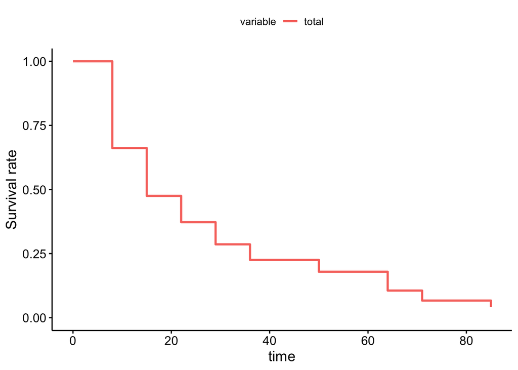

```r
#plotting something, can't remember what
ggadjustedcurves(tick18surv_model, data = tick18_final)
```

```r
#AIC comparison
AIC(tick18surv_model, tick18surv_model2, tick18surv_model3)
```

```
##                   df      AIC
## tick18surv_model  17 96374.83
## tick18surv_model2  5 96574.81
## tick18surv_model3  5 96574.81
```

### Plotting survival curve based on mean values of variables

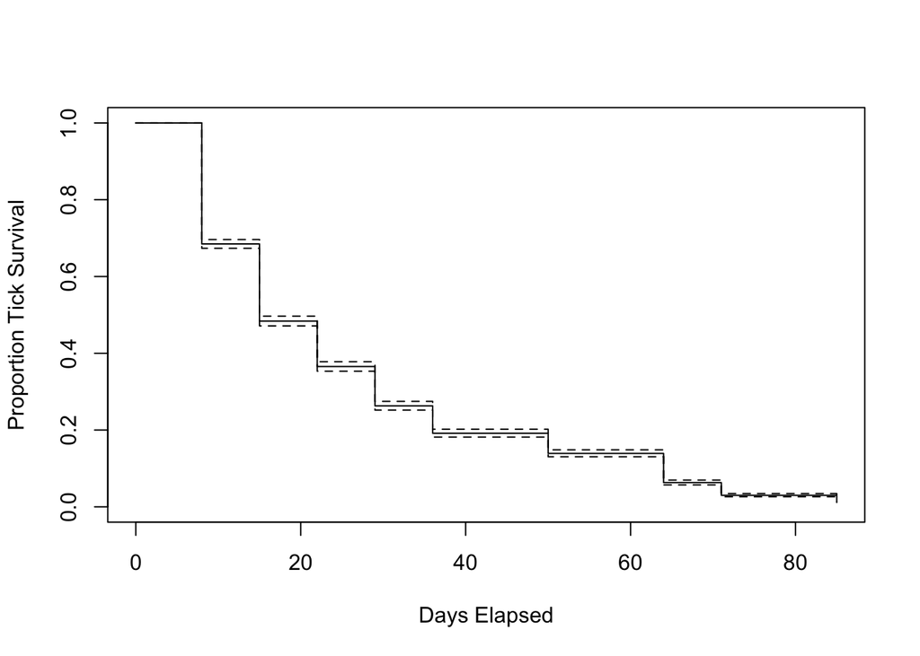

```r
## create survfit object and plot
tick18surv_fit<- survfit(tick18surv_model3)
plot(tick18surv_fit, xlab = "Days Elapsed", ylab ="Proportion Tick Survival")
```

# Data Analysis 2019

We are going to run a Cox Proportional Hazards model because that is appropriate for assessing the impacts of multiple variables on survival time. The Cox Proportional Hazards model is a type of non-parametric? semi-parametric (linear predictors) regression.

```r
#create the survival object
tick19_surv<- (Surv(tick19clean$days_elpsd, tick19clean$death_tf, type ="right"))

# create COX PH model with plot (exclosure) and site (climate) and the interaction, plus block as a random effect
tick19surv_model<-coxph(tick19_surv~ climate * exclosure + (1|block), data = tick19clean)
summary(tick19surv_model)
```

```
## Call:
## coxph(formula = tick19_surv ~ climate * exclosure + (1 | block),
##     data = tick19clean)
##
##   n= 132, number of events= 129
##
##                                         coef exp(coef) se(coef)      z
## climateIntermediate                  -1.4169    0.2425   0.3515 -4.031
## exclosurePartial                      0.1221    1.1298   0.3231  0.378
## exclosureTotal                        0.2126    1.2369   0.2900  0.733
## 1 | blockTRUE                             NA        NA   0.0000     NA
## climateIntermediate:exclosurePartial -0.4703    0.6248   0.4538 -1.036
## climateIntermediate:exclosureTotal   -0.0360    0.9646   0.4135 -0.087
##                                      Pr(>|z|)
## climateIntermediate                  5.55e-05 ***
## exclosurePartial                        0.706
## exclosureTotal                          0.464
## 1 | blockTRUE                              NA
## climateIntermediate:exclosurePartial    0.300
## climateIntermediate:exclosureTotal      0.931
## ---
## Signif. codes:  0 '***' 0.001 '**' 0.01 '*' 0.05 '.' 0.1 ' ' 1
##
##                                      exp(coef) exp(-coef) lower .95
## climateIntermediate                     0.2425     4.1242    0.1218
## exclosurePartial                        1.1298     0.8851    0.5997
## exclosureTotal                          1.2369     0.8085    0.7005
## 1 | blockTRUE                               NA         NA        NA
## climateIntermediate:exclosurePartial    0.6248     1.6005    0.2567
## climateIntermediate:exclosureTotal      0.9646     1.0367    0.4289
##                                      upper .95
## climateIntermediate                     0.4829
## exclosurePartial                        2.1284
## exclosureTotal                          2.1838
## 1 | blockTRUE                               NA
## climateIntermediate:exclosurePartial    1.5205
## climateIntermediate:exclosureTotal      2.1693
##
## Concordance= 0.627  (se = 0.042 )
## Likelihood ratio test= 43.07  on 5 df,   p=4e-08
## Wald test            = 36.06  on 5 df,   p=9e-07
## Score (logrank) test = 41.41  on 5 df,   p=8e-08
```

```r
# model without interaction term
tick19surv_model2<-coxph(tick19_surv~ climate + exclosure + (1|block), data = tick19clean)
summary(tick19surv_model2)
```

```
## Call:
## coxph(formula = tick19_surv ~ climate + exclosure + (1 | block),
##     data = tick19clean)
##
##   n= 132, number of events= 129
##
##                        coef exp(coef) se(coef)      z Pr(>|z|)
## climateIntermediate -1.5376    0.2149   0.2645 -5.812 6.16e-09 ***
## exclosurePartial    -0.1278    0.8800   0.2282 -0.560    0.575
## exclosureTotal       0.1923    1.2121   0.2064  0.932    0.351
## 1 | blockTRUE            NA        NA   0.0000     NA       NA
## ---
## Signif. codes:  0 '***' 0.001 '**' 0.01 '*' 0.05 '.' 0.1 ' ' 1
##
##                     exp(coef) exp(-coef) lower .95 upper .95
## climateIntermediate    0.2149      4.653    0.1280    0.3609
## exclosurePartial       0.8800      1.136    0.5627    1.3763
## exclosureTotal         1.2121      0.825    0.8088    1.8164
## 1 | blockTRUE              NA         NA        NA        NA
##
## Concordance= 0.62  (se = 0.042 )
## Likelihood ratio test= 41.84  on 3 df,   p=4e-09
## Wald test            = 35.63  on 3 df,   p=9e-08
## Score (logrank) test = 40.71  on 3 df,   p=8e-09
```

```r
#Anova(tick19surv_model2)

# without random block effect (only way I can get ANOVA to run)
tick19surv_model3<-coxph(tick19_surv~ climate + exclosure, data = tick19clean)
summary(tick19surv_model3)
```

```
## Call:
## coxph(formula = tick19_surv ~ climate + exclosure, data = tick19clean)
##
##   n= 132, number of events= 129
##
##                        coef exp(coef) se(coef)      z Pr(>|z|)
## climateIntermediate -1.5376    0.2149   0.2645 -5.812 6.16e-09 ***
## exclosurePartial    -0.1278    0.8800   0.2282 -0.560    0.575
## exclosureTotal       0.1923    1.2121   0.2064  0.932    0.351
## ---
## Signif. codes:  0 '***' 0.001 '**' 0.01 '*' 0.05 '.' 0.1 ' ' 1
##
##                     exp(coef) exp(-coef) lower .95 upper .95
## climateIntermediate    0.2149      4.653    0.1280    0.3609
## exclosurePartial       0.8800      1.136    0.5627    1.3763
## exclosureTotal         1.2121      0.825    0.8088    1.8164
##
## Concordance= 0.62  (se = 0.042 )
## Likelihood ratio test= 41.84  on 3 df,   p=4e-09
## Wald test            = 35.63  on 3 df,   p=9e-08
## Score (logrank) test = 40.71  on 3 df,   p=8e-09
```

```r
Anova(tick19surv_model3)
```

```
## Analysis of Deviance Table (Type II tests)
##           LR Chisq Df Pr(>Chisq)
## climate     39.850  1  2.743e-10 ***
## exclosure    2.025  2     0.3632
## ---
## Signif. codes:  0 '***' 0.001 '**' 0.01 '*' 0.05 '.' 0.1 ' ' 1
```

```r
#testing assumption of proportional hazards
cox.zph(tick19surv_model3)
```

```
##                         rho  chisq        p
## climateIntermediate -0.4047 35.170 3.02e-09
## exclosurePartial    -0.1054  1.500 2.21e-01
## exclosureTotal       0.0746  0.732 3.92e-01
## GLOBAL                   NA 39.190 1.58e-08
```

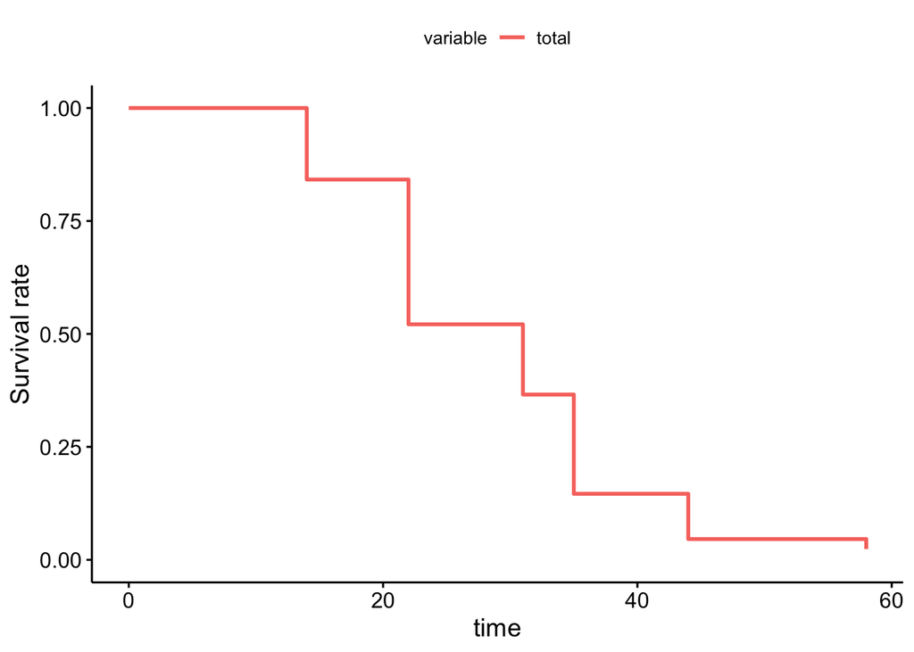

```r
#plotting something, can't remember what
ggadjustedcurves(tick19surv_model, data = tick19clean)
```

```r
#AIC comparison
AIC(tick19surv_model, tick19surv_model2, tick19surv_model3)
```

```
##                   df      AIC
## tick19surv_model   5 995.1233
## tick19surv_model2  3 992.3604
## tick19surv_model3  3 992.3604
```

### The following is from “Cox Proportional Hazards Regression for Survival Data in R” by Fox and Weisberg

- The column marked z in the output records the ratio of each regression coefficient to its standard error, a Wald statistic which is asymptotically standard normal under the hypothesis that the corresponding β is zero. The coefficients for the covariates age and prio (prior convictions) have very small p-values, while the coefficient for fin (financial aid—the focus of the study) has a p-value only slightly less than 0.05. - The exponentiated coefficients in the second column of the first panel (and in the first column of the second panel) of the output are interpretable as multiplicative effects on the hazard. Thus, for example, holding the other covariates constant, an additional year of age reduces the weekly hazard of rearrest by a factor of eb2 = 0.944 on average—that is, by 5.6 percent. Similarly, each prior conviction increases the hazard by a factor of 1.096, or 9.6 percent. - The likelihood-ratio, Wald, and score chi-square statistics at the bottom of the output are asymptotically equivalent tests of the omnibus null hypothesis that all of the βs are zero. In this instance, the test statistics are in close agreement, and the omnibus null hypothesis is soundly rejected.

### Plotting survival curve based on mean values of variables

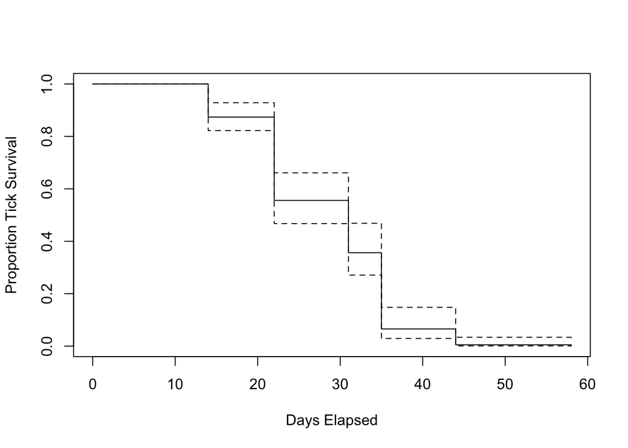

```r
## create survfit object and plot
tick19surv_fit<- survfit(tick19surv_model3)
plot(tick19surv_fit, xlab = "Days Elapsed", ylab ="Proportion Tick Survival")
```

### Instead, we want to plot a curve that indicates how survival changes with our variables of interest

- using “Cox Proportional Hazards Models in R” (in Evernote) p. 7
- we will first look at climate, holding all other variables to their mean (but we only have categorical variables…)
- the documentation I’m following says that for “dummy” variables ( I think it means categorical?), the “average value” is the proportion coded “Control” in the data set AND I HAVE NO IDEA WHAT THAT MEANS but I’m gonna try it
- currently not working so everything is hashtagged out

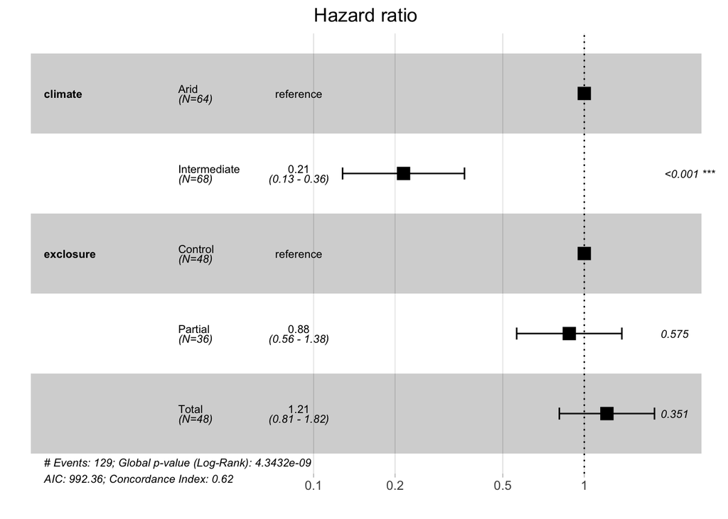

```r
# forest plots are a fun way to visualize model summary
ggforest(tick19surv_model3)
```

```r
#tick19_climate <- with(tick19clean, data.frame(climate = as.factor(c("Arid", "Intermediate")), exclosure = as.factor(rep(mean(exclosure == "Total"),2)), block = rep(mean(block)), microclimate = rep("open"),2))
# ^ this didn't work, see below

# coding a "categorical" variable didn't work at all, so i held it constant at "Total" exclosure for this figure
# I will then need to make another figure later for "Partial" exclosure
```

Creating the Total Exclosure x Climate Figure - plotting difference between intermediate and arid climates at total exclosure plots

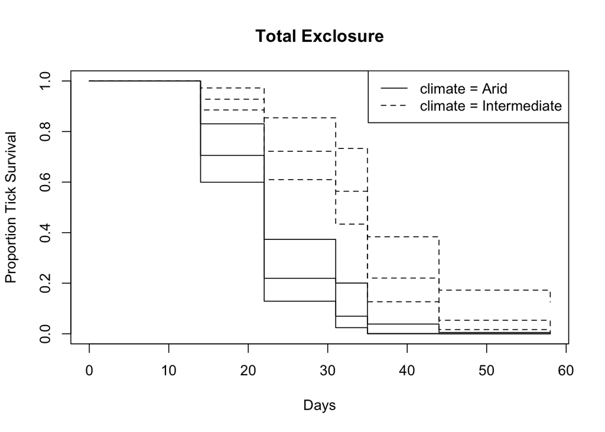

```r
tick19_climate_totalex <- with(tick19clean, data.frame(climate = c("Arid", "Intermediate"), exclosure = rep("Total"),2, block = rep(mean(block)), microclimate = rep("open"),2))

tick19_climate_totalex2 <- tick19_climate_totalex %>%
  select(climate, exclosure)

#now we predict

tickfit_totalex <- survfit(tick19surv_model3, newdata = tick19_climate_totalex2)
##getting an error that something isn't matching up

plot(tickfit_totalex,
     conf.int = TRUE,
     lty = c(1,2),
     ylab = "Proportion Tick Survival",
     xlab = "Days",
     main = "Total Exclosure")
     legend("topright",
            legend = c("climate = Arid", "climate = Intermediate"),
            lty = c(1,2))
```

```r
#ggadjustedcurves(tick19surv_model3,
#                 variable = climate,
#                 method = "conditional",
#                 data = tick19clean)

  #ggsurvplot(tickfit_totalex, data = tick19_climate_totalex2)
  # SUPER DUPER CUSTOMIZED PLOT
  # really want to make this work but currently having a hard time parsing the predicted curves and the ggsurv/ggadjusted curves model
#ggsurvplot(
#   tickfit_totalex,                            # survfit object with calculated statistics.
#   data = tick19_climate_totalex2,             # data used to fit survival curves.
#   risk.table = TRUE,       # show risk table.
#   pval = TRUE,             # show p-value of log-rank test.
#   conf.int = TRUE,         # show confidence intervals for
#                            # point estimates of survival curves.
#   xlim = c(0,60),          # present narrower X axis, but not affect
#                            # survival estimates.
#   xlab = "Time in days",   # customize X axis label.
#   break.time.by = 10,      # break X axis in time intervals by 500.
#   ggtheme = theme_light(), # customize plot and risk table with a theme.
# risk.table.y.text.col = T, # colour risk table text annotations.
#  risk.table.y.text = FALSE # show bars instead of names in text annotations in legend of risk table
#  #legend.labs = c()
#)
```

Creating the Partial Exclosure x Climate figure

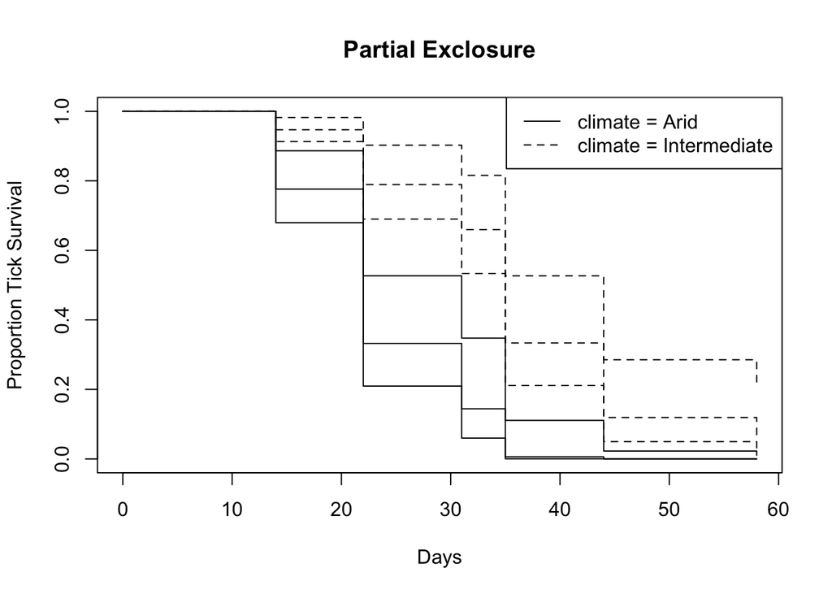

```r
tick19_climate_partialex <- with(tick19clean, data.frame(climate = c("Arid", "Intermediate"), exclosure = rep("Partial"),2, block = rep(mean(block)), microclimate = rep("open"),2))

tick19_climate_partialex2 <- tick19_climate_partialex %>%
  select(climate, exclosure)

#now we predict

tickfit_partialex <- survfit(tick19surv_model3, newdata = tick19_climate_partialex2)
##getting an error that something isn't matching up

plot(tickfit_partialex,
     conf.int = TRUE,
     lty = c(1,2),
     ylab = "Proportion Tick Survival",
     xlab = "Days",
     main = "Partial Exclosure")
     legend("topright",
            legend = c("climate = Arid", "climate = Intermediate"),
            lty = c(1,2))
```

Creating the Control Exclosure x Climate figure

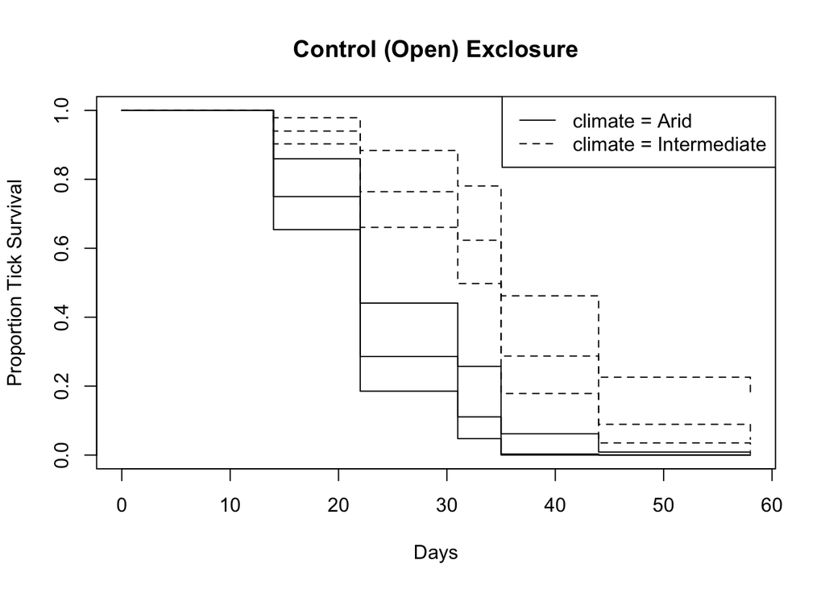

```r
tick19_climate_controlex <- with(tick19clean, data.frame(climate = c("Arid", "Intermediate"), exclosure = rep("Control"),2, block = rep(mean(block)), microclimate = rep("open"),2))

tick19_climate_controlex2 <- tick19_climate_controlex %>%
  select(climate, exclosure)

#now we predict

tickfit_controlex <- survfit(tick19surv_model3, newdata = tick19_climate_controlex2)
##getting an error that something isn't matching up

plot(tickfit_controlex,
     conf.int = TRUE,
     lty = c(1,2),
     ylab = "Proportion Tick Survival",
     xlab = "Days",
     main = "Control (Open) Exclosure")
     legend("topright",
            legend = c("climate = Arid", "climate = Intermediate"),
            lty = c(1,2))
```